# Data Analysis of eCommerce User Activity - by Ian Hudson

## Using 5 months of user activities from view to purchase to see if dependent Y (user likely to purchase or not), can be predicted.

## 20.6 million user events, upon 53,904 products from a Multi-category Online Store (MOS) eCommerce website.

# Let's get some useful libraries.

```python
import pandas as pd
import numpy as np
import matplotlib as mpl
from matplotlib import pyplot as plt
%matplotlib inline
import seaborn as sns
sns.set_style("darkgrid")
mpl.rcParams['figure.figsize'] = (20,5)
import statsmodels.api as sm # For Regression Modeling
import datetime # For converting and extracting datetime data
```

## Creating the Dataframe and converting the event_time column to datetime type

### Convert the event_time column to datetime type

```python
df = pd.read_csv('c:/load/ecommerce.csv',parse_dates=["event_time"])
```

### Checking the event_time data type

```python
df['event_time'].dtypes
```

```
datetime64[ns, UTC]
```

# Data Cleansing

## What does the dataframe look like?

```python
df.info()
```

```
<class 'pandas.core.frame.DataFrame'>
RangeIndex: 20692840 entries, 0 to 20692839
Data columns (total 10 columns):
 #   Column         Dtype
---  ------         -----
 0   Unnamed: 0     int64
 1   event_time     datetime64[ns, UTC]
 2   event_type     object
 3   product_id     int64
 4   category_id    int64
 5   category_code  object
 6   brand          object
 7   price          float64
 8   user_id        int64
 9   user_session   object
dtypes: datetime64[ns, UTC](1), float64(1), int64(4), object(4)
memory usage: 1.5+ GB
```

## Lets remove that unamed:0 column, it's a duplicate of the index column.

```python
df.drop(columns=['Unnamed: 0'],inplace=True)
```

### That column should now be gone, let's confirm

```python
df.columns
```

```
Index(['event_time', 'event_type', 'product_id', 'category_id',
       'category_code', 'brand', 'price', 'user_id', 'user_session'],
      dtype='object')
```

## Let's see if there are any missing values in columns

```python
df.isnull().sum()
```

```
event_time              0
event_type              0
product_id              0
category_id             0
category_code    20339246
brand             8757117
price                   0
user_id                 0
user_session         4598
dtype: int64
```

## There are some missing values in category_code, brand and user_session.

### Let's check out what percentage of data is missing.

```python
df.isnull().sum()/df.shape[0] * 100
```

```
event_time        0.000000
event_type        0.000000
product_id        0.000000
category_id       0.000000
category_code    98.291225
brand            42.319551
price             0.000000
user_id           0.000000
user_session      0.022220
dtype: float64
```

### 98% of category_code is missing, 42% of brand is missing, 0.02% of user_session is missing.

#### There is a huge amount of missing data for category_code and brand so I will drop these columns from the dataframe.

#### User_session will remain in the dataframe.

# Let's remove the category_code column

```python
if 'category_code' in df:
    df.drop(columns=['category_code'],inplace=True)
df.columns
```

```
Index(['event_time', 'event_type', 'product_id', 'category_id', 'brand',
       'price', 'user_id', 'user_session'],
      dtype='object')
```

# Let's also remove the brand column

```python
if 'brand' in df:
    df.drop(columns=['brand'],inplace=True)
df.columns
```

```
Index(['event_time', 'event_type', 'product_id', 'category_id', 'price',
       'user_id', 'user_session'],
      dtype='object')
```

# Let's remove any duplicate row data.

```python
df.drop_duplicates(inplace=True)
print('There are now ' + str(df.shape[0]) + ' rows.')
```

```
There are now 19583742 rows.
```

## Let's remove any leading or trailing spaces from string columns event_type and user_session

```python
df['event_type'] = df['event_type'].str.strip()
df['user_session'] = df['user_session'].str.strip()
```

# Now that the data is clean let's do some exploration

## To see the distribution of data, let's create some Histograms

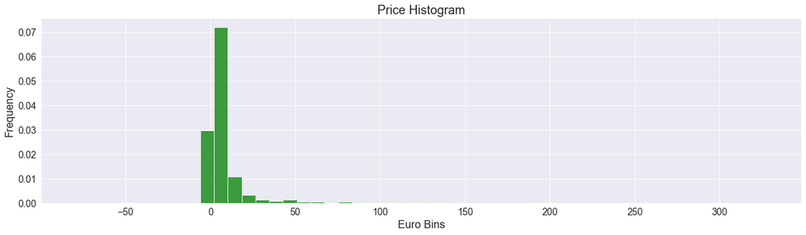

```python
plt.hist(df['price'], 50, density=True, facecolor='g', alpha=0.75)

plt.title('Price Histogram', fontsize = 18)
plt.xlabel('Euro Bins', fontsize = 16)
plt.ylabel('Frequency', fontsize = 16)
plt.xticks(fontsize=14)
plt.yticks(fontsize=14)
plt.show()
```

## The most common price is the 1 - 15 Euro range. Hmm, there seems to be some non-positive values in the price series, I'll have to check on that later

## Bar chart Event totals

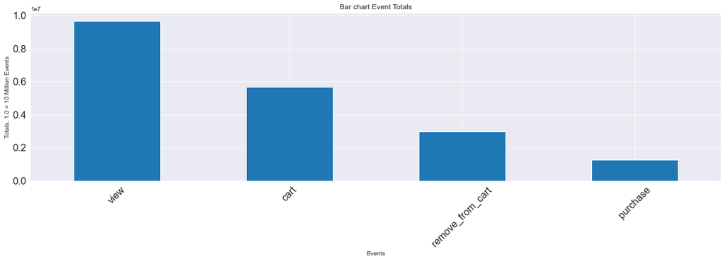

```python
df.event_type.value_counts().loc[['view', 'cart', 'remove_from_cart','purchase']].plot.bar(xlabel = "Events", ylabel = "Totals, 1.0 = 10 Million Events", title = "Bar chart Event Totals", rot = 45,fontsize = 16);
```

### The most frequent events are viewing products then putting products into the cart, removing a product from the cart and lastly making a purchase. Each event drops down to about half of the previous event.

## Let's see what the percentages are

```python
round(df['event_type'].value_counts(normalize = True),2)
```

```
view                0.49
cart                0.29
remove_from_cart    0.15
purchase            0.07
Name: event_type, dtype: float64
```

## What are the 'Event type' totals?

```python
df['event_type'].value_counts().sort_values(ascending=False)
```

```
view                9656790
cart                5652991
remove_from_cart    2987859
purchase            1286102
Name: event_type, dtype: int64
```

```python
df.price.max()
print('The highest price in the dataset is: '+ '$' + str(df.price.max()))
```

```
The highest price in the dataset is: $327.78
```

```python
df.price.min()
print('The lowest price in the dataset is: ' + '$' + str(df.price.min()))
```

```
The lowest price in the dataset is: $-79.37
```

## Why are there non-positive values in the 'price' column?

```python
df.sort_values(by=['price']).head()
```

|  | event_time | event_type | product_id | category_id | price | user_id | user_session |
| --- | --- | --- | --- | --- | --- | --- | --- |
| 13351304 | 2020-02-07 21:52:23+00:00 | purchase | 5716861 | 1487580014042939619 | -79.37 | 602831022 | c07648b8-c372-4936-b5ae-78b0f4236af9 |
| 4283228 | 2019-11-06 17:31:51+00:00 | purchase | 5716861 | 1487580014042939619 | -79.37 | 554241372 | b85719db-2c56-460b-b800-d7a47d4c4d70 |
| 19850269 | 2020-01-26 18:55:52+00:00 | purchase | 5716861 | 1487580014042939619 | -79.37 | 606448681 | 466cd335-b273-49a4-aefb-3077b5fcd87e |
| 17952565 | 2020-01-13 13:03:15+00:00 | purchase | 5716861 | 1487580014042939619 | -79.37 | 489184067 | 36f0ade4-fe9f-4353-9ddb-a6600e11b314 |
| 12938589 | 2020-02-05 07:57:45+00:00 | purchase | 5716861 | 1487580014042939619 | -79.37 | 562535575 | d243bb1b-2ee9-4c21-9b2a-6460469e9a75 |

## We will remove 'product refunds' (the non-positive price values) since they are beyond the scope of this analysis.

```python
df = df[~(df['price'] <= 0)] # Removing non-positive price value rows
```

```python
print('There are now ' + str(df.shape[0]) + ' rows and ' + str(df.shape[1]) + ' columns.')
```

```
There are now 19497292 rows and 7 columns.
```

### Checking to see if any still exsist ...

```python
df.sort_values(by=['price'],ascending = True).head()
```

|  | event_time | event_type | product_id | category_id | price | user_id | user_session |
| --- | --- | --- | --- | --- | --- | --- | --- |
| 8780080 | 2019-10-05 09:58:08+00:00 | cart | 5603938 | 1487580007717929935 | 0.05 | 556992916 | 2ff16c5f-d79e-4a44-ac2b-38ede7547a47 |
| 16054042 | 2020-02-27 10:12:14+00:00 | purchase | 5603934 | 1487580007717929935 | 0.05 | 565745379 | 5019ff7a-ca64-4098-ae8d-383c76d27500 |
| 8003423 | 2019-11-29 22:50:37+00:00 | view | 5603938 | 1487580007717929935 | 0.05 | 554216262 | 213f3248-fe64-4cda-a41b-1ac4f984610c |
| 993262 | 2019-12-08 19:38:03+00:00 | remove_from_cart | 5603937 | 1487580007717929935 | 0.05 | 518113830 | 313f0460-d950-4e63-93e3-852014a95338 |
| 16054043 | 2020-02-27 10:12:14+00:00 | purchase | 5603937 | 1487580007717929935 | 0.05 | 565745379 | 5019ff7a-ca64-4098-ae8d-383c76d27500 |

### Looks like we are ok now.

## What's the average price for a product?

```python
print('The average price of a product is '+ str(int(df['price'].mean() ))+ ' Euros.')
```

```
The average price of a product is 8 Euros.
```

## Let's see the unique value counts from select columns

```python
counter1 = len(df['event_type'].unique())
print('There are ' + str(counter1) + ' unique values in the ' + 'event_type column')
counter2 = len(df['product_id'].unique())
print('There are ' + str(counter2) + ' unique values in the ' + 'product_id column')
counter3 = len(df['category_id'].unique())
print('There are ' + str(counter3) + ' unique values in the ' + 'category_id column')
counter4 = len(df['price'].unique())
print('There are ' + str(counter4) + ' unique values in the ' + 'price column')
counter5 = len(df['user_id'].unique())
print('There are ' + str(counter5) + ' unique values in the ' + 'user_id column')
counter6 = len(df['user_session'].unique())
print('There are ' + str(counter6) + ' unique values in the ' + 'user_session column')
```

```
There are 4 unique values in the event_type column
There are 53904 unique values in the product_id column
There are 523 unique values in the category_id column
There are 2854 unique values in the price column
There are 1637977 unique values in the user_id column
There are 4520285 unique values in the user_session column
```

## What are the unique values for event_type?

```python
event_types = df['event_type'].unique()
print('Unique Event type: ' + event_types[0])
print('Unique Event type: ' + event_types[1])
print('Unique Event type: ' + event_types[2])
print('Unique Event type: ' + event_types[3])
```

```
Unique Event type: remove_from_cart
Unique Event type: view
Unique Event type: cart
Unique Event type: purchase
```

## How many unique Users are there?

```python
print('There are ' + str(len(df['user_id'].unique())) + ' unique Users.')
```

```
There are 1637977 unique Users.
```

# Creating new variables

## Let's create our Y dependent column

### 1 for 'purchased' and 0 for everything else

```python
df['purchased_yn'] = np.where(df['event_type']=='purchase', 1, 0)
```

```python
df['purchased_yn'].value_counts()
```

```
0    18211310
1     1285982
Name: purchased_yn, dtype: int64
```

```python
purchase_event_counts = df['purchased_yn'].value_counts()
print('There are ' + str(purchase_event_counts[1]) + ' purchase events and ' + str(purchase_event_counts[0]) + ' other events.')
purchase_event_percent = round((purchase_event_counts[1]) / (purchase_event_counts[0]),2) * 100
print('That is ' + str(purchase_event_percent) + '% of all events.')
```

```
There are 1285982 purchase events and 18211310 other events.
That is 7.000000000000001% of all events.
```

## Let's get the number of total purchases

```python
# Total number of purchases
total_num_purchases = len(df[(df.purchased_yn == 1)]) # 1 = Purchased
print('Total number of purchases is ' + str(total_num_purchases))

# Total number of purchases per day
total_num_purchases_daily = round(total_num_purchases / 152) # 152 days = 5 months of this dataset = purchases per day
print('Total number of purchases per day is ' + str(total_num_purchases_daily))

# Total number of purchases per month
total_num_purchases_monthly = round((total_num_purchases / 5))
print('Total number of purchases per month is ' + str(total_num_purchases_monthly))
```

```
Total number of purchases is 1285982
Total number of purchases per day is 8460
Total number of purchases per month is 257196
```

## Let's get the number of purchases per user

```python
# Number of purchases per User
df_g = df.query('purchased_yn == 1') # Query only the purchased (=1) items.
df_g = df_g.filter(['user_id','purchased_yn']) # Get only the needed columns.

# Number of purchases specific to the user_id
user_purchase_df = pd.DataFrame(df_g.groupby('user_id')['purchased_yn'].count()).reset_index()

# Merge the dataframes
user_purchase_df.columns = ['user_id','total_purchased']
df_joined = df.merge(user_purchase_df, how='left', on='user_id')

## Note primary dataframe name is now df_joined
```

```python
# Calculating average number of purchases
total_gotten = df_joined['total_purchased'].sum()
count_purchased = len(df_joined['total_purchased']==1)

avg_purchased = round(total_gotten / count_purchased,2)

print('Average number of purchases per user is: ' + (str(avg_purchased)))
```

```
Average number of purchases per user is: 18.94
```

## Let's create a number of sessions per user column

```python
# Number of sessions per User
df_h = df_joined.query('user_session > "1"') # Query only the user_sessions
df_h = df_h.filter(['user_id','user_session']) # Get only the needed columns.

# The number of sessions specific to (per) the user_id
user_session_df = pd.DataFrame(df_h.groupby('user_id')['user_session'].count()).reset_index()

# Merge the dataframes
user_session_df.columns = ['user_id','session_per_user']
df_joined = df_joined.merge(user_session_df, how='left', on='user_id')

df_joined
```

|  | event_time | event_type | product_id | category_id | price | user_id | user_session | purchased_yn | total_purchased | session_per_user |
| --- | --- | --- | --- | --- | --- | --- | --- | --- | --- | --- |
| 0 | 2019-12-01 00:00:00+00:00 | remove_from_cart | 5712790 | 1487580005268456287 | 6.27 | 576802932 | 51d85cb0-897f-48d2-918b-ad63965c12dc | 0 | 64.0 | 1266.0 |
| 1 | 2019-12-01 00:00:00+00:00 | view | 5764655 | 1487580005411062629 | 29.05 | 412120092 | 8adff31e-2051-4894-9758-224bfa8aec18 | 0 | 9.0 | 93.0 |
| 2 | 2019-12-01 00:00:02+00:00 | cart | 4958 | 1487580009471148064 | 1.19 | 494077766 | c99a50e8-2fac-4c4d-89ec-41c05f114554 | 0 | 50.0 | 127.0 |
| 3 | 2019-12-01 00:00:05+00:00 | view | 5848413 | 1487580007675986893 | 0.79 | 348405118 | 722ffea5-73c0-4924-8e8f-371ff8031af4 | 0 | NaN | 85.0 |
| 4 | 2019-12-01 00:00:07+00:00 | view | 5824148 | 1487580005511725929 | 5.56 | 576005683 | 28172809-7e4a-45ce-bab0-5efa90117cd5 | 0 | NaN | 57.0 |
| ... | ... | ... | ... | ... | ... | ... | ... | ... | ... | ... |
| 19497287 | 2020-01-31 23:59:52+00:00 | view | 5796984 | 1487580005671109489 | 1.73 | 417102560 | dcf90ff3-a246-4b00-b39a-83e6444a0769 | 0 | NaN | 26.0 |
| 19497288 | 2020-01-31 23:59:52+00:00 | remove_from_cart | 5886774 | 1487580006317032337 | 1.59 | 607092857 | a4ccd1c4-a9d2-48d0-9816-082ec5bb5e47 | 0 | 11.0 | 57.0 |
| 19497289 | 2020-01-31 23:59:53+00:00 | view | 5875432 | 2084144451428549153 | 2.05 | 423651741 | fb42a963-abef-4c4f-b1ba-f5812dd54e80 | 0 | NaN | 85.0 |
| 19497290 | 2020-01-31 23:59:57+00:00 | remove_from_cart | 5820745 | 1487580006317032337 | 2.22 | 607092857 | a4ccd1c4-a9d2-48d0-9816-082ec5bb5e47 | 0 | 11.0 | 57.0 |
| 19497291 | 2020-01-31 23:59:58+00:00 | remove_from_cart | 5820745 | 1487580006317032337 | 2.22 | 607092857 | a4ccd1c4-a9d2-48d0-9816-082ec5bb5e47 | 0 | 11.0 | 57.0 |

19497292 rows × 10 columns

## Let's get the event levels per user

```python
# Making a column based on which event the user reached
conditions = [
    (df_joined['event_type'] =='view'), # = 1
    (df_joined['event_type'] =='cart'), # = 2
    (df_joined['event_type'] =='remove_from_cart'), # = 3
    (df_joined['event_type'] =='purchase')] # = 4
choices = [1,2,3,4]
df_joined['event_type_level'] = np.select(conditions,choices,default = 1)

# Adding event_level per user.
event_level_per_user_df = pd.DataFrame(df_joined.groupby('user_id')['event_type_level'].nunique()).reset_index()
event_level_per_user_df

# Merge it back into main dataframe
event_level_per_user_df.columns = ['user_id','event_type_stage']
df_joined = df_joined.merge(event_level_per_user_df, how='left', on='user_id')
```

```python
df_joined
```

|  | event_time | event_type | product_id | category_id | price | user_id | user_session | purchased_yn | total_purchased | session_per_user | event_type_level | event_type_stage |
| --- | --- | --- | --- | --- | --- | --- | --- | --- | --- | --- | --- | --- |
| 0 | 2019-12-01 00:00:00+00:00 | remove_from_cart | 5712790 | 1487580005268456287 | 6.27 | 576802932 | 51d85cb0-897f-48d2-918b-ad63965c12dc | 0 | 64.0 | 1266.0 | 3 | 4 |
| 1 | 2019-12-01 00:00:00+00:00 | view | 5764655 | 1487580005411062629 | 29.05 | 412120092 | 8adff31e-2051-4894-9758-224bfa8aec18 | 0 | 9.0 | 93.0 | 1 | 4 |
| 2 | 2019-12-01 00:00:02+00:00 | cart | 4958 | 1487580009471148064 | 1.19 | 494077766 | c99a50e8-2fac-4c4d-89ec-41c05f114554 | 0 | 50.0 | 127.0 | 2 | 4 |
| 3 | 2019-12-01 00:00:05+00:00 | view | 5848413 | 1487580007675986893 | 0.79 | 348405118 | 722ffea5-73c0-4924-8e8f-371ff8031af4 | 0 | NaN | 85.0 | 1 | 3 |
| 4 | 2019-12-01 00:00:07+00:00 | view | 5824148 | 1487580005511725929 | 5.56 | 576005683 | 28172809-7e4a-45ce-bab0-5efa90117cd5 | 0 | NaN | 57.0 | 1 | 3 |
| ... | ... | ... | ... | ... | ... | ... | ... | ... | ... | ... | ... | ... |
| 19497287 | 2020-01-31 23:59:52+00:00 | view | 5796984 | 1487580005671109489 | 1.73 | 417102560 | dcf90ff3-a246-4b00-b39a-83e6444a0769 | 0 | NaN | 26.0 | 1 | 2 |
| 19497288 | 2020-01-31 23:59:52+00:00 | remove_from_cart | 5886774 | 1487580006317032337 | 1.59 | 607092857 | a4ccd1c4-a9d2-48d0-9816-082ec5bb5e47 | 0 | 11.0 | 57.0 | 3 | 4 |
| 19497289 | 2020-01-31 23:59:53+00:00 | view | 5875432 | 2084144451428549153 | 2.05 | 423651741 | fb42a963-abef-4c4f-b1ba-f5812dd54e80 | 0 | NaN | 85.0 | 1 | 3 |
| 19497290 | 2020-01-31 23:59:57+00:00 | remove_from_cart | 5820745 | 1487580006317032337 | 2.22 | 607092857 | a4ccd1c4-a9d2-48d0-9816-082ec5bb5e47 | 0 | 11.0 | 57.0 | 3 | 4 |
| 19497291 | 2020-01-31 23:59:58+00:00 | remove_from_cart | 5820745 | 1487580006317032337 | 2.22 | 607092857 | a4ccd1c4-a9d2-48d0-9816-082ec5bb5e47 | 0 | 11.0 | 57.0 | 3 | 4 |

19497292 rows × 12 columns

## Let's get the average event duration per user in minutes

```python
# Average event time per user
df_joined['aet_per_user'] = df_joined.event_time.dt.minute.rolling(window=3).mean()
df_aet = df_joined.filter(['aet_per_user','user_id']) # Get only the needed columns.

# Average event duration specific to (per) the user_id
avg_event_time_df = pd.DataFrame(df_aet.groupby('user_id')['aet_per_user'].mean().reset_index())

# Merge the dataframes
avg_event_time_df.columns = ['user_id','avg_evt_dur_per_user']
df_joined = df_joined.merge(avg_event_time_df, how='left', on='user_id')

df_joined
```

|  | event_time | event_type | product_id | category_id | price | user_id | user_session | purchased_yn | total_purchased | session_per_user | event_type_level | event_type_stage | aet_per_user | avg_evt_dur_per_user |
| --- | --- | --- | --- | --- | --- | --- | --- | --- | --- | --- | --- | --- | --- | --- |
| 0 | 2019-12-01 00:00:00+00:00 | remove_from_cart | 5712790 | 1487580005268456287 | 6.27 | 576802932 | 51d85cb0-897f-48d2-918b-ad63965c12dc | 0 | 64.0 | 1266.0 | 3 | 4 | NaN | 28.854893 |
| 1 | 2019-12-01 00:00:00+00:00 | view | 5764655 | 1487580005411062629 | 29.05 | 412120092 | 8adff31e-2051-4894-9758-224bfa8aec18 | 0 | 9.0 | 93.0 | 1 | 4 | NaN | 31.261649 |
| 2 | 2019-12-01 00:00:02+00:00 | cart | 4958 | 1487580009471148064 | 1.19 | 494077766 | c99a50e8-2fac-4c4d-89ec-41c05f114554 | 0 | 50.0 | 127.0 | 2 | 4 | 0.0 | 26.860892 |
| 3 | 2019-12-01 00:00:05+00:00 | view | 5848413 | 1487580007675986893 | 0.79 | 348405118 | 722ffea5-73c0-4924-8e8f-371ff8031af4 | 0 | NaN | 85.0 | 1 | 3 | 0.0 | 31.337255 |
| 4 | 2019-12-01 00:00:07+00:00 | view | 5824148 | 1487580005511725929 | 5.56 | 576005683 | 28172809-7e4a-45ce-bab0-5efa90117cd5 | 0 | NaN | 57.0 | 1 | 3 | 0.0 | 35.134503 |
| ... | ... | ... | ... | ... | ... | ... | ... | ... | ... | ... | ... | ... | ... | ... |
| 19497287 | 2020-01-31 23:59:52+00:00 | view | 5796984 | 1487580005671109489 | 1.73 | 417102560 | dcf90ff3-a246-4b00-b39a-83e6444a0769 | 0 | NaN | 26.0 | 1 | 2 | 59.0 | 30.269231 |
| 19497288 | 2020-01-31 23:59:52+00:00 | remove_from_cart | 5886774 | 1487580006317032337 | 1.59 | 607092857 | a4ccd1c4-a9d2-48d0-9816-082ec5bb5e47 | 0 | 11.0 | 57.0 | 3 | 4 | 59.0 | 44.251142 |
| 19497289 | 2020-01-31 23:59:53+00:00 | view | 5875432 | 2084144451428549153 | 2.05 | 423651741 | fb42a963-abef-4c4f-b1ba-f5812dd54e80 | 0 | NaN | 85.0 | 1 | 3 | 59.0 | 29.880759 |
| 19497290 | 2020-01-31 23:59:57+00:00 | remove_from_cart | 5820745 | 1487580006317032337 | 2.22 | 607092857 | a4ccd1c4-a9d2-48d0-9816-082ec5bb5e47 | 0 | 11.0 | 57.0 | 3 | 4 | 59.0 | 44.251142 |
| 19497291 | 2020-01-31 23:59:58+00:00 | remove_from_cart | 5820745 | 1487580006317032337 | 2.22 | 607092857 | a4ccd1c4-a9d2-48d0-9816-082ec5bb5e47 | 0 | 11.0 | 57.0 | 3 | 4 | 59.0 | 44.251142 |

19497292 rows × 14 columns

```python
df_joined['avg_evt_dur_per_user'].mean()
print('Average event time per user in minutes is: ' +  str(df_joined['avg_evt_dur_per_user'].mean()))
```

```
Average event time per user in minutes is: 29.64472128317097
```

## Day of week, most purchases, per user

```python
# Day of week, most purchases, per user
df_joined['max_purch_dow_per_user']= df_joined['event_time'].dt.dayofweek
max_purch_dow = df_joined.filter(['max_purch_dow_per_user','user_id']) # Get only the needed columns.

# day of week of most purchases specific to (per) the user_id
max_purch_dow_per_user_df = pd.DataFrame(max_purch_dow.groupby('user_id')['max_purch_dow_per_user'].max().reset_index())

# Merge the dataframes
max_purch_dow_per_user_df.columns = ['user_id','max_purch_dayofweek']
df_joined = df_joined.merge(max_purch_dow_per_user_df, how='left', on='user_id')

df_joined
```

|  | event_time | event_type | product_id | category_id | price | user_id | user_session | purchased_yn | total_purchased | session_per_user | event_type_level | event_type_stage | aet_per_user | avg_evt_dur_per_user | max_purch_dow_per_user | max_purch_dayofweek |
| --- | --- | --- | --- | --- | --- | --- | --- | --- | --- | --- | --- | --- | --- | --- | --- | --- |
| 0 | 2019-12-01 00:00:00+00:00 | remove_from_cart | 5712790 | 1487580005268456287 | 6.27 | 576802932 | 51d85cb0-897f-48d2-918b-ad63965c12dc | 0 | 64.0 | 1266.0 | 3 | 4 | NaN | 28.854893 | 6 | 6 |
| 1 | 2019-12-01 00:00:00+00:00 | view | 5764655 | 1487580005411062629 | 29.05 | 412120092 | 8adff31e-2051-4894-9758-224bfa8aec18 | 0 | 9.0 | 93.0 | 1 | 4 | NaN | 31.261649 | 6 | 6 |
| 2 | 2019-12-01 00:00:02+00:00 | cart | 4958 | 1487580009471148064 | 1.19 | 494077766 | c99a50e8-2fac-4c4d-89ec-41c05f114554 | 0 | 50.0 | 127.0 | 2 | 4 | 0.0 | 26.860892 | 6 | 6 |
| 3 | 2019-12-01 00:00:05+00:00 | view | 5848413 | 1487580007675986893 | 0.79 | 348405118 | 722ffea5-73c0-4924-8e8f-371ff8031af4 | 0 | NaN | 85.0 | 1 | 3 | 0.0 | 31.337255 | 6 | 6 |
| 4 | 2019-12-01 00:00:07+00:00 | view | 5824148 | 1487580005511725929 | 5.56 | 576005683 | 28172809-7e4a-45ce-bab0-5efa90117cd5 | 0 | NaN | 57.0 | 1 | 3 | 0.0 | 35.134503 | 6 | 6 |
| ... | ... | ... | ... | ... | ... | ... | ... | ... | ... | ... | ... | ... | ... | ... | ... | ... |
| 19497287 | 2020-01-31 23:59:52+00:00 | view | 5796984 | 1487580005671109489 | 1.73 | 417102560 | dcf90ff3-a246-4b00-b39a-83e6444a0769 | 0 | NaN | 26.0 | 1 | 2 | 59.0 | 30.269231 | 4 | 5 |
| 19497288 | 2020-01-31 23:59:52+00:00 | remove_from_cart | 5886774 | 1487580006317032337 | 1.59 | 607092857 | a4ccd1c4-a9d2-48d0-9816-082ec5bb5e47 | 0 | 11.0 | 57.0 | 3 | 4 | 59.0 | 44.251142 | 4 | 6 |
| 19497289 | 2020-01-31 23:59:53+00:00 | view | 5875432 | 2084144451428549153 | 2.05 | 423651741 | fb42a963-abef-4c4f-b1ba-f5812dd54e80 | 0 | NaN | 85.0 | 1 | 3 | 59.0 | 29.880759 | 4 | 5 |
| 19497290 | 2020-01-31 23:59:57+00:00 | remove_from_cart | 5820745 | 1487580006317032337 | 2.22 | 607092857 | a4ccd1c4-a9d2-48d0-9816-082ec5bb5e47 | 0 | 11.0 | 57.0 | 3 | 4 | 59.0 | 44.251142 | 4 | 6 |
| 19497291 | 2020-01-31 23:59:58+00:00 | remove_from_cart | 5820745 | 1487580006317032337 | 2.22 | 607092857 | a4ccd1c4-a9d2-48d0-9816-082ec5bb5e47 | 0 | 11.0 | 57.0 | 3 | 4 | 59.0 | 44.251142 | 4 | 6 |

19497292 rows × 16 columns

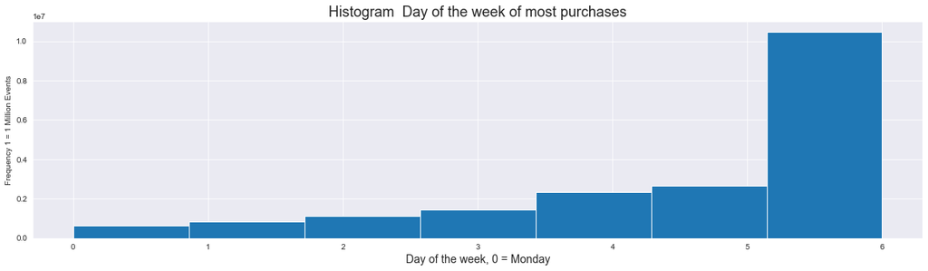

```python
df_joined['max_purch_dayofweek'].plot(kind = 'hist', bins = 7)
plt.title('Histogram  Day of the week of most purchases', fontsize = 18)
plt.ylabel('Frequency 1 = 1 Million Events')
plt.xlabel('Day of the week, 0 = Monday', fontsize = 14);
```

# Let's Investigate outliers with Box plots

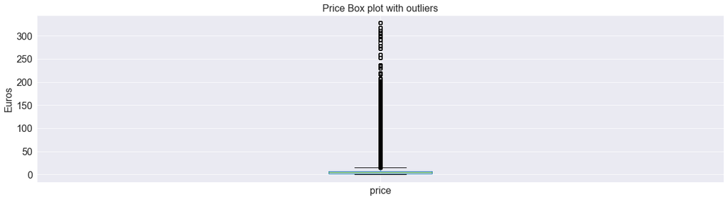

```python
df_joined.boxplot(column='price', return_type='axes',fontsize = 16)
plt.title('Price Box plot with outliers',fontsize = 16)
plt.ylabel('Euros',fontsize = 16)
plt.show()
```

### Let's identify our outliers

```python
Q1 = df_joined.price.quantile(0.25)
Q3 = df_joined.price.quantile(0.75)
IQR = Q3 - Q1

Lower_Limit = Q1 - 1.5 * IQR
Upper_Limit = Q3 + 1.5 * IQR

cols = list(['price'])
no_outliers = df_joined.price[~((df_joined[cols] < (Lower_Limit)) | (df_joined[cols] > (Upper_Limit))).any(axis=1)]

outliers_percent = len(no_outliers)/len(df_joined)
percentage = int(outliers_percent * 100)
print('The percentage of the dataset left after outliers are removed from "price" column is: ' + str(percentage) + '%')
```

```
The percentage of the dataset left after outliers are removed from "price" column is: 89%
```

## Adjusted - Price Box plot

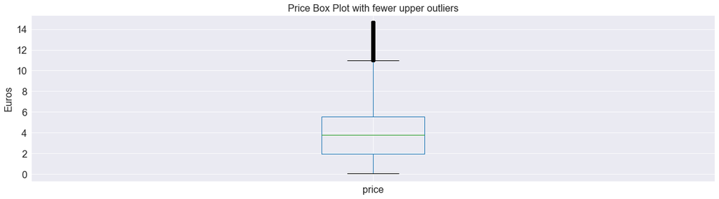

```python
no_outliers.plot(kind='box',fontsize = 16)
plt.title('Price Box Plot with fewer upper outliers',fontsize = 16)
plt.ylabel('Euros',fontsize = 16)
plt.show()
```

# Investigate Correlations

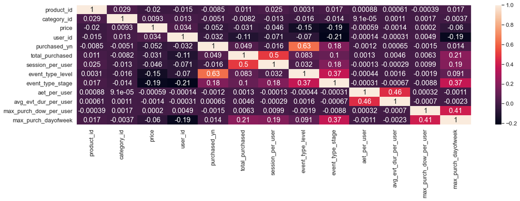

```python
df_corr = df_joined.corr()
sns.set(font_scale=1.2)
sns.heatmap(df_corr, annot=True, annot_kws={"size":16})
```

## Bar plot of Correlated Features

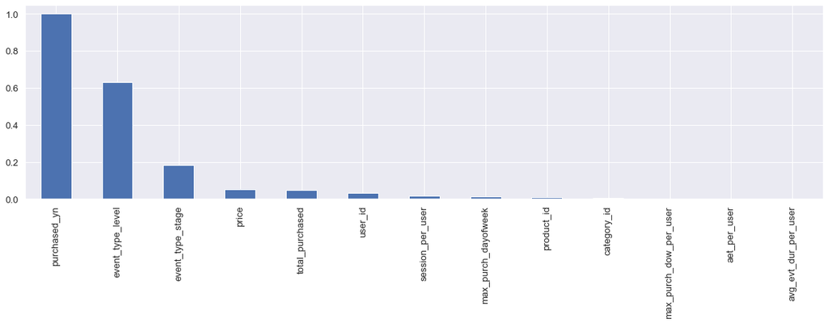

```python
df_corr_features = df_joined.corr()
df_corr_features['purchased_yn'].apply(abs).sort_values(ascending=False).plot(kind='bar')
plt.show()
```

```python
df_joined = df_joined.dropna()
# independent_variables = df_joined['effectiveness'] # R2 = 0.002
# independent_variables = df_joined[['event_type_level','price','user_event_type_level','min_price_per_user']] #R2 = 0.403
# independent_variables = df_joined[['event_type_level','user_event_type_level','price','min_price_per_product','total_purchased','min_price_per_user','session_per_user']] #R2 = 0.509
# independent_variables = df_joined[['event_type_level','price','total_purchased','min_price_per_user']] # R2 = 0.501
# independent_variables = df_joined[['event_type_level','price','min_price_per_user']] # R2 = 0.501
# independent_variables = df_joined[['event_type_level','price','min_price_per_user','avg_evt_dur_per_user']] # R2 = 0.501
# independent_variables = df_joined[['event_type_level','price','avg_evt_dur_per_user','max_purch_dow_per_user_y']] # R2 = 0.504
# independent_variables = df_joined[['event_type_level','user_event_type_level','effectiveness']] # R2 = 0.505
# independent_variables = df_joined[['event_type_level','user_event_type_level','effectiveness','max_purch_dayofweek']] # R2 = 0.507
# independent_variables = df_joined[['event_type_stage','effectiveness']] # R2 = 0.500
# independent_variables = df_joined[['event_type_stage','event_type_level']] # R2 = 0.505
independent_variables = df_joined['event_type_level'] # R2 = 0.499
dependent_variable = df_joined['purchased_yn']
independent_variables = sm.add_constant(independent_variables)
regression_model = sm.OLS(dependent_variable,independent_variables).fit()
regression_model.summary()
```

OLS Regression Results

| Dep. Variable: | purchased_yn | R-squared: | 0.499 |
| --- | --- | --- | --- |
| Model: | OLS | Adj. R-squared: | 0.499 |
| Method: | Least Squares | F-statistic: | 1.072e+07 |
| Date: | Mon, 14 Mar 2022 | Prob (F-statistic): | 0.00 |
| Time: | 13:23:54 | Log-Likelihood: | 5.9852e+05 |
| No. Observations: | 10748521 | AIC: | -1.197e+06 |
| Df Residuals: | 10748519 | BIC: | -1.197e+06 |
| Df Model: | 1 |  |  |
| Covariance Type: | nonrobust |  |  |

|  | coef | std err | t | P>\|t\| | [0.025 | 0.975] |
| --- | --- | --- | --- | --- | --- | --- |
| const | -0.3352 | 0.000 | -2159.743 | 0.000 | -0.335 | -0.335 |
| event_type_level | 0.2235 | 6.83e-05 | 3274.883 | 0.000 | 0.223 | 0.224 |

| Omnibus: | 322831.910 | Durbin-Watson: | 1.074 |
| --- | --- | --- | --- |
| Prob(Omnibus): | 0.000 | Jarque-Bera (JB): | 247703.815 |
| Skew: | 0.284 | Prob(JB): | 0.00 |
| Kurtosis: | 2.521 | Cond. No. | 5.86 |

Notes:  
[1] Standard Errors assume that the covariance matrix of the errors is correctly specified.

# Notes:

Achieving accuracy of more than 50 percent is improbable in cases where prediction is related to psychology, as we don't know the user's mindset at the time of purchase. In some fields, it is entirely expected that an R-squared value would be low. For example, any field that attempts to predict human behavior. That is precisely what we are doing in this analysis. Considering this 0.499 is a good fit to the model.

# Summary

- The most common price is the 1 - 15 Euro range.
- The most frequent events are viewing products then putting products into the cart,  
  removing a product from the cart and lastly making a purchase.
- On average each 'event_type' amount drops down to about half the amount of the previous 'event_type'.

*Event Type percentages:*  
| view | 0.49 || cart | 0.29 || remove_from_cart | 0.15 || purchase | 0.07 |

## Insights

Expensive shipping is a significant reason why users will remove products from the cart.

A key would be to analyze why users remove nearly 1/2 of the cart contents before making a purchase. This may indicate that shipping prices are too high versus the total amount of the purchase. For example, a user may find it difficult to justify an 8 Euro purchase while having to pay 10 additional Euros for shipping.

## Recommendations

1. Get shipping prices. Expensive shipping is another reason users will remove products from the cart. Also get variables for multiple shipping options, if available.
1. Get a complete list of product names and categories. This dataset identified most only as a reference number.
2. Get 1 or more years of data. This datasets purchase events are a very small percentage of the dataset.
3. Online user polling may help to reveal any user/usage 'pain points'.

# Exporting analyzed dataset to CSV file

```python
df_joined.to_csv('./ecommerce_analyzed.csv', encoding='utf-8')
```